# Fangorn

The purpose of this document is to create random forest models for the data set. This task is accomplished by taking the test data as subset it into three categories based on variance. A variance threshold of 0.5 that incapsulates the top 20% most variant genes, a variance threshold of 1 that incapsulates the top 10% most variant genes, and a variance threshold of 1.5 that incapsulates the top 5% most variant genes. A secondary RMD file was created later on to test for the top 1% most variant genes. The decision was made for these thresholds after not having enough computing power to train on the entire dataset these filters were applied because it was felt that they would capture enough of the important variables present in the file to build a decent predictive model. After the training set is subset into its different category each variance level has a clean names filter applied to it to fix any lingering naming issues that may be present. Then each of the variant files has a drug column applied to it one at a time so the first set is drug one and so on. This set of three is then run an initial time to get a baseline with the default settings of the randomforest() function including a split per tree of 3 and 500 trees. First the trees are optimized by seeing the error rate per tree and the overall out of bag rate for each model the graphing allows the user to see where the trees begin to level out. The user then manually adjusts the number of trees in the model until the graph shows a leveling out in the 3 categories. For each variance model this is optimized, once this step is complete using the new tree count a loop is run where each model is created 20 times with varying splits from 1-20. From this the error rates for each model is displayed and the one with the lowest is chosen as the split number for the model. This new split number and tree number are then fed back into the randomforest() function and the final model is created for that drug/variance level combination. This step is reproduced 12 times once for each drug resulting in the creation of 36 over all models. From these models the model with the lowest out of bag error rate was chosen to move on to the next step.

Note as the code can be slightly confusing due to its size a key is provided: oldForest=5% variance model any number after this name is indicative of the drug used in combination with the model

mirkwood=10% variance model any number after this name is indicative of the drug used in combination with the model

fangorn=20% variance model any number after this name is indicative of the drug used in combination with the model

treex5= the five percent variance table fed to the random forest model that is a concatenation of both the test set and the drug for that section

treex10= the ten percent variance table fed to the random forest model that is a concatenation of both the test set and the drug for that section

treex20= the twenty percent variance table fed to the random forest model that is a concatenation of both the test set and the drug for that section

```r
set.seed(25000)
library(tidyverse)
library(ggplot2)
library(cowplot)
library(randomForest)
library(parallel)
library(skimr)
library(broom)
library(janitor)
library(dplyr)
library(readr)
library(genefilter)
#library(parLapply)
```

```r
# Read in the cleaned expression data
expression <- as.data.frame((read.table("../data/clean_expression.txt", row.names=1 )))
rownames(expression)[1] <- '184A1'# Rename the only integer name
# Read in the subtype data
subtypes <- read_tsv("../data/clean_subtypes.txt")
# Read in the truth set
truth_set <-  as.data.frame((read.table("../data/clean_training_answers.txt", row.names=1 )))
# Create merged feature set
featureSet<-cbind(subtypes[,2],t(expression))
```

# variance

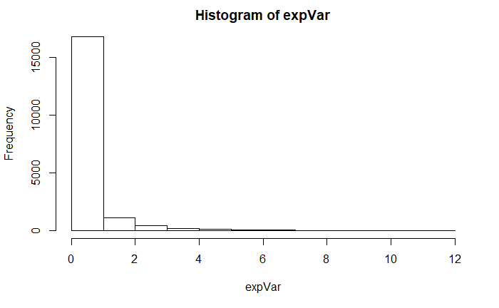

```r
expVar <- (rowVars(expression))
hist(expVar)
```

```r
expVar <- as.data.frame(expVar)
names(expVar) <- c('variance')
paste('max variance:', max(expVar[,1]))
```

```
[1] "max variance: 11.2727797404595"
```

```r
paste('min variance:', min(expVar[,1]))
```

```
[1] "min variance: 0.0149762247525575"
```

```r
#top 20 of genes
expVar %>% count((variance > '0.5'))
```

| (variance > "0.5") | n |
| --- | --- |
| FALSE | 14835 |
| TRUE | 3797 |

```r
top20 <- expVar$variance > 0.5
root20 <- expression[top20,]
root20<-data.frame(t(root20))
dim(root20)
```

```
[1]   25 3797
```

```r
#top 10% of genes
expVar %>% count((variance > '1'))
```

| (variance > "1") | n |
| --- | --- |
| FALSE | 16824 |
| TRUE | 1808 |

```r
top10 <- expVar$variance > 1
root10 <- expression[top10,]
root10<-data.frame(t(root10))
dim(root10)
```

```
[1]   25 1808
```

```r
#top 5% of genes
expVar %>% count((variance > '1.5'))
```

| (variance > "1.5") | n |
| --- | --- |
| FALSE | 17554 |
| TRUE | 1078 |

```r
top5 <- expVar$variance > 1.5
root5 <- expression[top5,]
root5<-data.frame(t(root5))
dim(root5)
```

```
[1]   25 1078
```

# forest 1

```r
#straping the first column of the truth set to the tree
tree120<-cbind(drug=truth_set[,1],root20)
tree120<-clean_names(tree120)
tree120$drug<-factor(tree120$drug)
tree110<-cbind(drug=truth_set[,1],root10)
tree110<-clean_names(tree110)
tree110$drug<-factor(tree110$drug)
tree105<-cbind(drug=truth_set[,1],root5)
tree105<-clean_names(tree105)
tree105$drug<-factor(tree105$drug)
```

```r
set.seed(25000)
#BAROOM dont be hasty now

oldForest <- randomForest( drug∼.,data=tree105  ,mtry=3,ntree=2000)
oldForest

mirkwood <- randomForest( drug∼.,data=tree110  ,mtry=3,ntree=2000)
mirkwood

fangorn <- randomForest( drug∼.,data=tree120  ,mtry=3,ntree=2000)
fangorn
```

[output not shown]

```r
set.seed(25000)
#tree optimization for 5% tree
oob.error.oldForest <- data.frame(
  Trees=rep(1:nrow(oldForest$err.rate), times=3),
  Type=rep(c("OOB", "1", "0"), each=nrow(oldForest$err.rate)),
  Error=c(oldForest$err.rate[,"OOB"],
    oldForest$err.rate[,"1"],
    oldForest$err.rate[,"0"]))

#tree optimization for 10% tree
oob.error.mirkwood <- data.frame(
  Trees=rep(1:nrow(mirkwood$err.rate), times=3),
  Type=rep(c("OOB", "1", "0"), each=nrow(mirkwood$err.rate)),
  Error=c(mirkwood$err.rate[,"OOB"],
    mirkwood$err.rate[,"1"],
    mirkwood$err.rate[,"0"]))

#tree optimization for 20% tree
oob.error.fangorn<- data.frame(
  Trees=rep(1:nrow(fangorn$err.rate), times=3),
  Type=rep(c("OOB", "1", "0"), each=nrow(fangorn$err.rate)),
  Error=c(fangorn$err.rate[,"OOB"],
    fangorn$err.rate[,"1"],
    fangorn$err.rate[,"0"]))

#tree optimization plot for 5% tree
ggplot(data=oob.error.oldForest, aes(x=Trees, y=Error)) +
  geom_line(aes(color=Type))+ggtitle("forest of 5% variance")

#tree optimization plot for 10% tree
ggplot(data=oob.error.mirkwood, aes(x=Trees, y=Error)) +
  geom_line(aes(color=Type))+ggtitle("forest of 10% variance")

#tree optimization for 20% tree
ggplot(data=oob.error.fangorn, aes(x=Trees, y=Error)) +
  geom_line(aes(color=Type))+ggtitle("forest of 20% variance")
```

[output not shown]

```r
set.seed(25000)
#split optimization
oob.values <- vector(length=20)
for(i in 1:20) {
  temp.model <- randomForest(drug ~ ., data=tree105, mtry=i, ntree=2000)
  oob.values[i] <- temp.model$err.rate[nrow(temp.model$err.rate),1]
}
oob.values
```

```
 [1] 0.56 0.60 0.52 0.56 0.56 0.52 0.56 0.52 0.52 0.64 0.52 0.52 0.48 0.60 0.52 0.60 0.52 0.52 0.52 0.60
```

```r
oob.values <- vector(length=20)
for(i in 1:20) {
  temp.model <- randomForest(drug ~ ., data=tree110, mtry=i, ntree=2000)
  oob.values[i] <- temp.model$err.rate[nrow(temp.model$err.rate),1]
}
oob.values
```

```
 [1] 0.60 0.64 0.60 0.56 0.52 0.56 0.52 0.60 0.56 0.56 0.52 0.60 0.52 0.52 0.52 0.56 0.56 0.48 0.60 0.56
```

```r
oob.values <- vector(length=20)
for(i in 1:20) {
  temp.model <- randomForest(drug ~ ., data=tree120, mtry=i, ntree=2000)
  oob.values[i] <- temp.model$err.rate[nrow(temp.model$err.rate),1]
}
oob.values
```

```
 [1] 0.52 0.56 0.56 0.64 0.52 0.56 0.56 0.56 0.60 0.52 0.52 0.56 0.56 0.52 0.60 0.60 0.60 0.56 0.56 0.52
```

```r
set.seed(25000)
#BAROOM dont be hasty now

#assumes that 0.48 is the lowest
oldForest <- randomForest( drug∼.,data=tree105  ,mtry=13,ntree=2000)
oldForest

#assumes that 0.48 is the lowest
mirkwood <- randomForest( drug∼.,data=tree110  ,mtry=18,ntree=2000)
mirkwood

#assumes that 0.52 is the lowest
fangorn <- randomForest( drug∼.,data=tree120  ,mtry=5,ntree=2000)
fangorn
```

# forest 2

```r
tree220<-cbind(drug=truth_set[,2],root20)
tree220<-clean_names(tree220)
tree220$drug<-factor(tree220$drug)
tree210<-cbind(drug=truth_set[,2],root10)
tree210<-clean_names(tree210)
tree210$drug<-factor(tree210$drug)
tree205<-cbind(drug=truth_set[,2],root5)
tree205<-clean_names(tree205)
tree205$drug<-factor(tree205$drug)
```

```r
set.seed(25000)
#BAROOM dont be hasty now
oldForest2 <- randomForest( drug∼.,data=tree205  ,mtry=3,ntree=500)
oldForest2
```

```
Call:
 randomForest(formula = drug ~ ., data = tree205, mtry = 3, ntree = 500)
               Type of random forest: classification
                     Number of trees: 500
No. of variables tried at each split: 3

        OOB estimate of  error rate: 20%
Confusion matrix:
   0 1 class.error
0 11 2   0.1538462
1  3 9   0.2500000
```

```r
mirkwood2 <- randomForest( drug∼.,data=tree210  ,mtry=3,ntree=500)
mirkwood2
```

```
Call:
 randomForest(formula = drug ~ ., data = tree210, mtry = 3, ntree = 500)
               Type of random forest: classification
                     Number of trees: 500
No. of variables tried at each split: 3

        OOB estimate of  error rate: 20%
Confusion matrix:
   0 1 class.error
0 11 2   0.1538462
1  3 9   0.2500000
```

```r
fangorn2 <- randomForest( drug∼.,data=tree220  ,mtry=3,ntree=500)
fangorn2
```

```
Call:
 randomForest(formula = drug ~ ., data = tree220, mtry = 3, ntree = 500)
               Type of random forest: classification
                     Number of trees: 500
No. of variables tried at each split: 3

        OOB estimate of  error rate: 20%
Confusion matrix:
   0 1 class.error
0 11 2   0.1538462
1  3 9   0.2500000
```

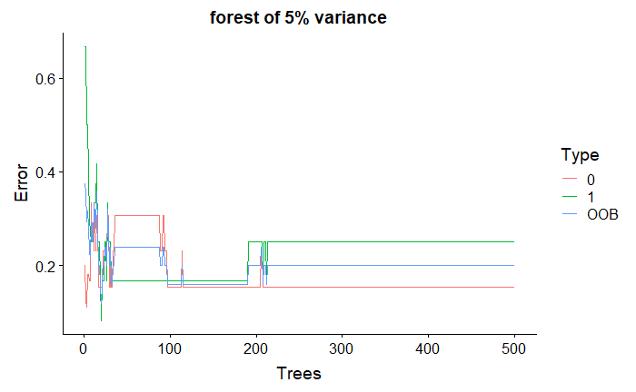

```r
#tree optimization for 5% tree
oob.error.oldForest2 <- data.frame(
  Trees=rep(1:nrow(oldForest2$err.rate), times=3),
  Type=rep(c("OOB", "1", "0"), each=nrow(oldForest2$err.rate)),
  Error=c(oldForest2$err.rate[,"OOB"],
    oldForest2$err.rate[,"1"],
    oldForest2$err.rate[,"0"]))
#tree optimization for 10% tree
oob.error.mirkwood2 <- data.frame(
  Trees=rep(1:nrow(mirkwood2$err.rate), times=3),
  Type=rep(c("OOB", "1", "0"), each=nrow(mirkwood2$err.rate)),
  Error=c(mirkwood2$err.rate[,"OOB"],
    mirkwood2$err.rate[,"1"],
    mirkwood2$err.rate[,"0"]))
#tree optimization for 20% tree
oob.error.fangorn2<- data.frame(
  Trees=rep(1:nrow(fangorn2$err.rate), times=3),
  Type=rep(c("OOB", "1", "0"), each=nrow(fangorn2$err.rate)),
  Error=c(fangorn2$err.rate[,"OOB"],
    fangorn2$err.rate[,"1"],
    fangorn2$err.rate[,"0"]))
#tree optimization plot for 5% tree
ggplot(data=oob.error.oldForest2, aes(x=Trees, y=Error)) +
  geom_line(aes(color=Type))+ggtitle("forest of 5% variance")
```

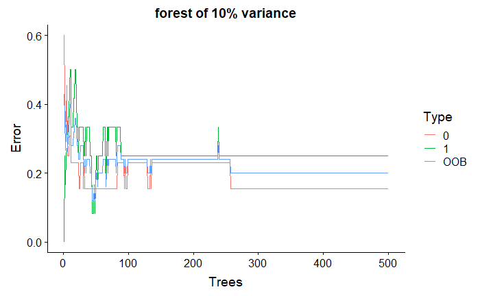

```r
#tree optimization plot for 10% tree
ggplot(data=oob.error.mirkwood2, aes(x=Trees, y=Error)) +
  geom_line(aes(color=Type))+ggtitle("forest of 10% variance")
```

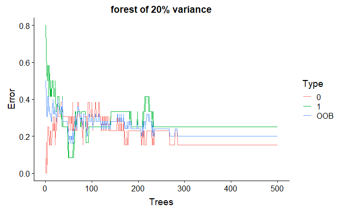

```r
#tree optimization for 20% tree
ggplot(data=oob.error.fangorn2, aes(x=Trees, y=Error)) +
  geom_line(aes(color=Type))+ggtitle("forest of 20% variance")
```

```r
set.seed(25000)
#split optimization
oob.values <- vector(length=20)
for(i in 1:20) {
  temp.model <- randomForest(drug ~ ., data=tree205, mtry=i, ntree=500)
  oob.values[i] <- temp.model$err.rate[nrow(temp.model$err.rate),1]
}
oob.values
```

```
 [1] 0.20 0.20 0.20 0.24 0.28 0.20 0.24 0.20 0.20 0.20 0.20 0.20 0.20 0.20 0.28 0.20 0.20 0.20 0.28 0.20
```

```r
oob.values <- vector(length=20)
for(i in 1:20) {
  temp.model <- randomForest(drug ~ ., data=tree210, mtry=i, ntree=500)
  oob.values[i] <- temp.model$err.rate[nrow(temp.model$err.rate),1]
}
oob.values
```

```
 [1] 0.20 0.20 0.20 0.20 0.20 0.20 0.24 0.20 0.20 0.20 0.20 0.20 0.20 0.24 0.20 0.20 0.20 0.24 0.20 0.24
```

```r
oob.values <- vector(length=20)
for(i in 1:20) {
  temp.model <- randomForest(drug ~ ., data=tree220, mtry=i, ntree=500)
  oob.values[i] <- temp.model$err.rate[nrow(temp.model$err.rate),1]
}
oob.values
```

```
 [1] 0.24 0.20 0.24 0.24 0.20 0.28 0.24 0.24 0.20 0.24 0.24 0.24 0.24 0.24 0.24 0.28 0.28 0.24 0.24 0.24
```

```r
set.seed(25000)
#BAROOM dont be hasty now
oldForest2 <- randomForest( drug∼.,data=tree205  ,mtry=2,ntree=500)
oldForest2
```

```
Call:
 randomForest(formula = drug ~ ., data = tree205, mtry = 2, ntree = 500)
               Type of random forest: classification
                     Number of trees: 500
No. of variables tried at each split: 2

        OOB estimate of  error rate: 20%
Confusion matrix:
   0 1 class.error
0 11 2   0.1538462
1  3 9   0.2500000
```

```r
mirkwood2 <- randomForest( drug∼.,data=tree210  ,mtry=2,ntree=500)
mirkwood2
```

```
Call:
 randomForest(formula = drug ~ ., data = tree210, mtry = 2, ntree = 500)
               Type of random forest: classification
                     Number of trees: 500
No. of variables tried at each split: 2

        OOB estimate of  error rate: 20%
Confusion matrix:
   0 1 class.error
0 11 2   0.1538462
1  3 9   0.2500000
```

```r
fangorn2 <- randomForest( drug∼.,data=tree220  ,mtry=2,ntree=500)
fangorn2
```

```
Call:
 randomForest(formula = drug ~ ., data = tree220, mtry = 2, ntree = 500)
               Type of random forest: classification
                     Number of trees: 500
No. of variables tried at each split: 2

        OOB estimate of  error rate: 24%
Confusion matrix:
   0 1 class.error
0 10 3   0.2307692
1  3 9   0.2500000
```

# forest drug 3

```r
#straping the first column of the truth set to the tree
tree320<-cbind(drug=truth_set[,3],root20)
tree320<-clean_names(tree320)
tree320$drug<-factor(tree320$drug)
tree310<-cbind(drug=truth_set[,3],root10)
tree310<-clean_names(tree310)
tree310$drug<-factor(tree310$drug)
tree305<-cbind(drug=truth_set[,3],root5)
tree305<-clean_names(tree305)
tree305$drug<-factor(tree305$drug)
```

```r
set.seed(25000)
#BAROOM dont be hasty now
oldForest3 <- randomForest( drug∼.,data=tree305  ,mtry=3,ntree=1000)
oldForest3
```

```
Call:
 randomForest(formula = drug ~ ., data = tree305, mtry = 3, ntree = 1000)
               Type of random forest: classification
                     Number of trees: 1000
No. of variables tried at each split: 3

        OOB estimate of  error rate: 8%
Confusion matrix:
  0  1 class.error
0 8  2         0.2
1 0 15         0.0
```

```r
mirkwood3 <- randomForest( drug∼.,data=tree310  ,mtry=3,ntree=1000)
mirkwood3
```

```
Call:
 randomForest(formula = drug ~ ., data = tree310, mtry = 3, ntree = 1000)
               Type of random forest: classification
                     Number of trees: 1000
No. of variables tried at each split: 3

        OOB estimate of  error rate: 12%
Confusion matrix:
  0  1 class.error
0 8  2  0.20000000
1 1 14  0.06666667
```

```r
fangorn3 <- randomForest( drug∼.,data=tree320  ,mtry=3,ntree=500)
fangorn3
```

```
Call:
 randomForest(formula = drug ~ ., data = tree320, mtry = 3, ntree = 500)
               Type of random forest: classification
                     Number of trees: 500
No. of variables tried at each split: 3

        OOB estimate of  error rate: 16%
Confusion matrix:
  0  1 class.error
0 7  3  0.30000000
1 1 14  0.06666667
```

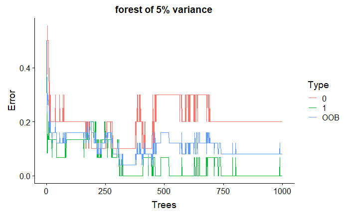

```r
#tree optimization for 5% tree
oob.error.oldForest3 <- data.frame(
  Trees=rep(1:nrow(oldForest3$err.rate), times=3),
  Type=rep(c("OOB", "1", "0"), each=nrow(oldForest3$err.rate)),
  Error=c(oldForest3$err.rate[,"OOB"],
    oldForest3$err.rate[,"1"],
    oldForest3$err.rate[,"0"]))
#tree optimization for 10% tree
oob.error.mirkwood3 <- data.frame(
  Trees=rep(1:nrow(mirkwood3$err.rate), times=3),
  Type=rep(c("OOB", "1", "0"), each=nrow(mirkwood3$err.rate)),
  Error=c(mirkwood3$err.rate[,"OOB"],
    mirkwood3$err.rate[,"1"],
    mirkwood3$err.rate[,"0"]))
#tree optimization for 20% tree
oob.error.fangorn3<- data.frame(
  Trees=rep(1:nrow(fangorn3$err.rate), times=3),
  Type=rep(c("OOB", "1", "0"), each=nrow(fangorn3$err.rate)),
  Error=c(fangorn3$err.rate[,"OOB"],
    fangorn3$err.rate[,"1"],
    fangorn3$err.rate[,"0"]))
#tree optimization plot for 5% tree
ggplot(data=oob.error.oldForest3, aes(x=Trees, y=Error)) +
  geom_line(aes(color=Type))+ggtitle("forest of 5% variance")
```

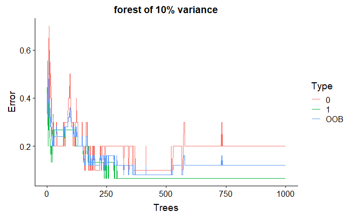

```r
#tree optimization plot for 10% tree
ggplot(data=oob.error.mirkwood3, aes(x=Trees, y=Error)) +
  geom_line(aes(color=Type))+ggtitle("forest of 10% variance")
```

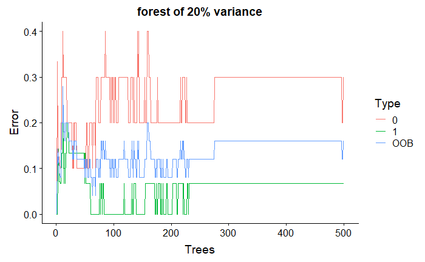

```r
#tree optimization for 20% tree
ggplot(data=oob.error.fangorn3, aes(x=Trees, y=Error)) +
  geom_line(aes(color=Type))+ggtitle("forest of 20% variance")
```

```r
set.seed(25000)
#split optimization
oob.values <- vector(length=20)
for(i in 1:20) {
  temp.model <- randomForest(drug ~ ., data=tree305, mtry=i, ntree=1000)
  oob.values[i] <- temp.model$err.rate[nrow(temp.model$err.rate),1]
}
oob.values
```

```
 [1] 0.12 0.12 0.08 0.12 0.08 0.12 0.12 0.12 0.12 0.04 0.08 0.04 0.12 0.04 0.08 0.12 0.08 0.08 0.04 0.08
```

```r
oob.values <- vector(length=20)
for(i in 1:20) {
  temp.model <- randomForest(drug ~ ., data=tree310, mtry=i, ntree=1000)
  oob.values[i] <- temp.model$err.rate[nrow(temp.model$err.rate),1]
}
oob.values
```

```
 [1] 0.12 0.12 0.12 0.12 0.12 0.08 0.08 0.04 0.08 0.04 0.12 0.16 0.08 0.08 0.04 0.04 0.08 0.04 0.04 0.12
```

```r
oob.values <- vector(length=20)
for(i in 1:20) {
  temp.model <- randomForest(drug ~ ., data=tree320, mtry=i, ntree=500)
  oob.values[i] <- temp.model$err.rate[nrow(temp.model$err.rate),1]
}
oob.values
```

```
 [1] 0.16 0.12 0.12 0.16 0.12 0.04 0.08 0.12 0.08 0.04 0.12 0.08 0.04 0.08 0.08 0.12 0.08 0.08 0.12 0.08
```

```r
set.seed(25000)
#BAROOM dont be hasty now
oldForest2 <- randomForest( drug∼.,data=tree205  ,mtry=2,ntree=1000)
oldForest2
```

```
Call:
 randomForest(formula = drug ~ ., data = tree205, mtry = 2, ntree = 1000)
               Type of random forest: classification
                     Number of trees: 1000
No. of variables tried at each split: 2

        OOB estimate of  error rate: 20%
Confusion matrix:
   0 1 class.error
0 11 2   0.1538462
1  3 9   0.2500000
```

```r
mirkwood2 <- randomForest( drug∼.,data=tree210  ,mtry=2,ntree=1000)
mirkwood2
```

```
Call:
 randomForest(formula = drug ~ ., data = tree210, mtry = 2, ntree = 1000)
               Type of random forest: classification
                     Number of trees: 1000
No. of variables tried at each split: 2

        OOB estimate of  error rate: 20%
Confusion matrix:
   0 1 class.error
0 11 2   0.1538462
1  3 9   0.2500000
```

```r
fangorn2 <- randomForest( drug∼.,data=tree220  ,mtry=2,ntree=500)
fangorn2
```

```
Call:
 randomForest(formula = drug ~ ., data = tree220, mtry = 2, ntree = 500)
               Type of random forest: classification
                     Number of trees: 500
No. of variables tried at each split: 2

        OOB estimate of  error rate: 20%
Confusion matrix:
   0 1 class.error
0 11 2   0.1538462
1  3 9   0.2500000
```

# drug 4

```r
#straping the forth column of the truth set to the tree for each percent
tree420<-cbind(drug=truth_set[,4],root20)
tree420<-clean_names(tree420)
tree420$drug<-factor(tree420$drug)


tree410<-cbind(drug=truth_set[,4],root10)
tree410<-clean_names(tree410)
tree410$drug<-factor(tree410$drug)


tree405<-cbind(drug=truth_set[,4],root5)
tree405<-clean_names(tree405)
tree405$drug<-factor(tree405$drug)
```

```r
set.seed(25000)
#BAROOM dont be hasty now
oldForest4 <- randomForest( drug∼.,data=tree405  ,mtry=3,ntree=500)
oldForest4
```

```
Call:
 randomForest(formula = drug ~ ., data = tree405, mtry = 3, ntree = 500)
               Type of random forest: classification
                     Number of trees: 500
No. of variables tried at each split: 3

        OOB estimate of  error rate: 36%
Confusion matrix:
   0 1 class.error
0 16 1  0.05882353
1  8 0  1.00000000
```

```r
mirkwood4 <- randomForest( drug∼.,data=tree410  ,mtry=3,ntree=500)
mirkwood4
```

```
Call:
 randomForest(formula = drug ~ ., data = tree410, mtry = 3, ntree = 500)
               Type of random forest: classification
                     Number of trees: 500
No. of variables tried at each split: 3

        OOB estimate of  error rate: 36%
Confusion matrix:
   0 1 class.error
0 16 1  0.05882353
1  8 0  1.00000000
```

```r
fangorn4 <- randomForest( drug∼.,data=tree420  ,mtry=3,ntree=500)
fangorn4
```

```
Call:
 randomForest(formula = drug ~ ., data = tree420, mtry = 3, ntree = 500)
               Type of random forest: classification
                     Number of trees: 500
No. of variables tried at each split: 3

        OOB estimate of  error rate: 40%
Confusion matrix:
   0 1 class.error
0 15 2   0.1176471
1  8 0   1.0000000
```

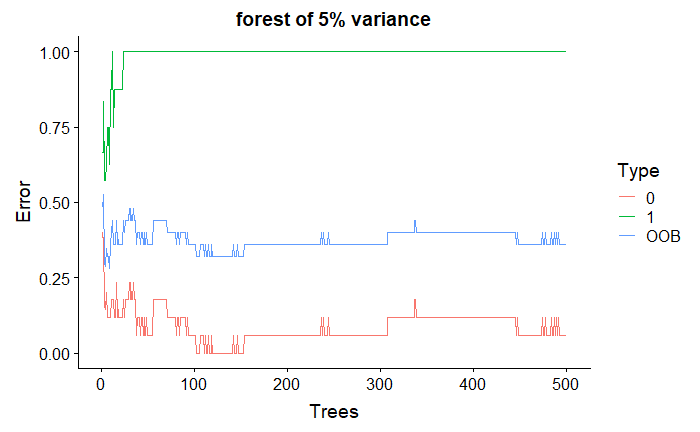

```r
#tree optimization for 5% tree
oob.error.oldForest4 <- data.frame(
  Trees=rep(1:nrow(oldForest4$err.rate), times=3),
  Type=rep(c("OOB", "1", "0"), each=nrow(oldForest4$err.rate)),
  Error=c(oldForest4$err.rate[,"OOB"],
    oldForest4$err.rate[,"1"],
    oldForest4$err.rate[,"0"]))
#tree optimization for 10% tree
oob.error.mirkwood4 <- data.frame(
  Trees=rep(1:nrow(mirkwood4$err.rate), times=3),
  Type=rep(c("OOB", "1", "0"), each=nrow(mirkwood4$err.rate)),
  Error=c(mirkwood4$err.rate[,"OOB"],
    mirkwood4$err.rate[,"1"],
    mirkwood4$err.rate[,"0"]))
#tree optimization for 20% tree
oob.error.fangorn4<- data.frame(
  Trees=rep(1:nrow(fangorn4$err.rate), times=3),
  Type=rep(c("OOB", "1", "0"), each=nrow(fangorn4$err.rate)),
  Error=c(fangorn4$err.rate[,"OOB"],
    fangorn4$err.rate[,"1"],
    fangorn4$err.rate[,"0"]))
#tree optimization plot for 5% tree
ggplot(data=oob.error.oldForest4, aes(x=Trees, y=Error)) +
  geom_line(aes(color=Type))+ggtitle("forest of 5% variance")
```

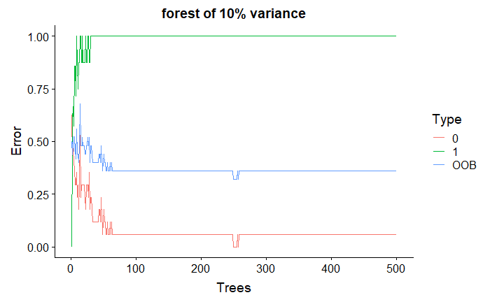

```r
#tree optimization plot for 10% tree
ggplot(data=oob.error.mirkwood4, aes(x=Trees, y=Error)) +
  geom_line(aes(color=Type))+ggtitle("forest of 10% variance")
```

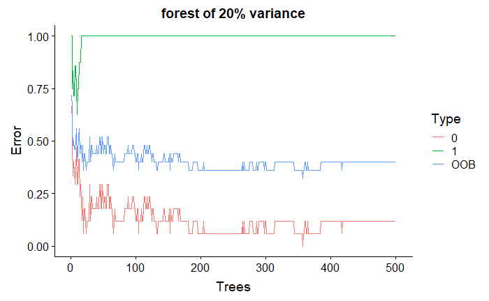

```r
#tree optimization for 20% tree
ggplot(data=oob.error.fangorn4, aes(x=Trees, y=Error)) +
  geom_line(aes(color=Type))+ggtitle("forest of 20% variance")
```

```r
set.seed(25000)
#split optimization
oob.values <- vector(length=20)
for(i in 1:20) {
  temp.model <- randomForest(drug ~ ., data=tree405, mtry=i, ntree=500)
  oob.values[i] <- temp.model$err.rate[nrow(temp.model$err.rate),1]
}
oob.values
```

```
 [1] 0.36 0.36 0.40 0.36 0.40 0.36 0.40 0.44 0.44 0.40 0.40 0.36 0.40 0.36 0.40 0.40 0.40 0.44 0.40 0.36
```

```r
oob.values <- vector(length=20)
for(i in 1:20) {
  temp.model <- randomForest(drug ~ ., data=tree410, mtry=i, ntree=500)
  oob.values[i] <- temp.model$err.rate[nrow(temp.model$err.rate),1]
}
oob.values
```

```
 [1] 0.32 0.40 0.44 0.40 0.40 0.36 0.40 0.44 0.40 0.36 0.44 0.40 0.40 0.40 0.40 0.32 0.36 0.40 0.40 0.40
```

```r
oob.values <- vector(length=20)
for(i in 1:20) {
  temp.model <- randomForest(drug ~ ., data=tree420, mtry=i, ntree=500)
  oob.values[i] <- temp.model$err.rate[nrow(temp.model$err.rate),1]
}
oob.values
```

```
 [1] 0.32 0.32 0.36 0.36 0.32 0.36 0.36 0.36 0.32 0.36 0.36 0.36 0.36 0.36 0.36 0.36 0.36 0.36 0.40 0.40
```

```r
set.seed(25000)
#BAROOM dont be hasty now

oldForest4 <- randomForest( drug∼.,data=tree405  ,mtry=2,ntree=1000)
oldForest4

mirkwood4 <- randomForest( drug∼.,data=tree410  ,mtry=1,ntree=1000)
mirkwood4

fangorn4 <- randomForest( drug∼.,data=tree420  ,mtry=2,ntree=500)
fangorn4
```

# drug 5

```r
#straping the first column of the truth set to the tree
tree520<-cbind(drug=truth_set[,5],root20)
tree520<-clean_names(tree520)
tree520$drug<-factor(tree520$drug)
tree510<-cbind(drug=truth_set[,5],root10)
tree510<-clean_names(tree510)
tree510$drug<-factor(tree510$drug)
tree505<-cbind(drug=truth_set[,5],root5)
tree505<-clean_names(tree505)
tree505$drug<-factor(tree505$drug)
```

```r
set.seed(25000)
#BAROOM dont be hasty now
oldForest5 <- randomForest( drug∼.,data=tree505  ,mtry=3,ntree=500)
oldForest5
```

```
Call:
 randomForest(formula = drug ~ ., data = tree505, mtry = 3, ntree = 500)
               Type of random forest: classification
                     Number of trees: 500
No. of variables tried at each split: 3

        OOB estimate of  error rate: 28%
Confusion matrix:
  0  1 class.error
0 6  4         0.4
1 3 12         0.2
```

```r
mirkwood5 <- randomForest( drug∼.,data=tree510  ,mtry=3,ntree=1000)
mirkwood5
```

```
Call:
 randomForest(formula = drug ~ ., data = tree510, mtry = 3, ntree = 1000)
               Type of random forest: classification
                     Number of trees: 1000
No. of variables tried at each split: 3

        OOB estimate of  error rate: 36%
Confusion matrix:
  0  1 class.error
0 5  5   0.5000000
1 4 11   0.2666667
```

```r
fangorn5 <- randomForest( drug∼.,data=tree520  ,mtry=3,ntree=500)
fangorn5
```

```
Call:
 randomForest(formula = drug ~ ., data = tree520, mtry = 3, ntree = 500)
               Type of random forest: classification
                     Number of trees: 500
No. of variables tried at each split: 3

        OOB estimate of  error rate: 36%
Confusion matrix:
  0  1 class.error
0 5  5   0.5000000
1 4 11   0.2666667
```

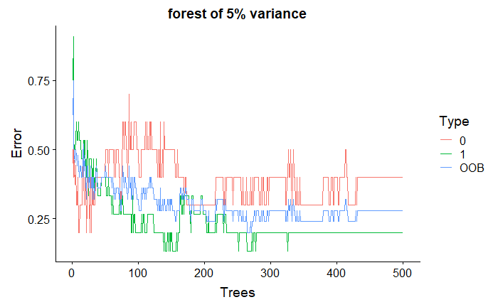

```r
#tree optimization for 5% tree
oob.error.oldForest5 <- data.frame(
  Trees=rep(1:nrow(oldForest5$err.rate), times=3),
  Type=rep(c("OOB", "1", "0"), each=nrow(oldForest5$err.rate)),
  Error=c(oldForest5$err.rate[,"OOB"],
    oldForest5$err.rate[,"1"],
    oldForest5$err.rate[,"0"]))
#tree optimization for 10% tree
oob.error.mirkwood5 <- data.frame(
  Trees=rep(1:nrow(mirkwood5$err.rate), times=3),
  Type=rep(c("OOB", "1", "0"), each=nrow(mirkwood5$err.rate)),
  Error=c(mirkwood5$err.rate[,"OOB"],
    mirkwood5$err.rate[,"1"],
    mirkwood5$err.rate[,"0"]))
#tree optimization for 20% tree
oob.error.fangorn5<- data.frame(
  Trees=rep(1:nrow(fangorn5$err.rate), times=3),
  Type=rep(c("OOB", "1", "0"), each=nrow(fangorn5$err.rate)),
  Error=c(fangorn5$err.rate[,"OOB"],
    fangorn5$err.rate[,"1"],
    fangorn5$err.rate[,"0"]))
#tree optimization plot for 5% tree
ggplot(data=oob.error.oldForest5, aes(x=Trees, y=Error)) +
  geom_line(aes(color=Type))+ggtitle("forest of 5% variance")
```

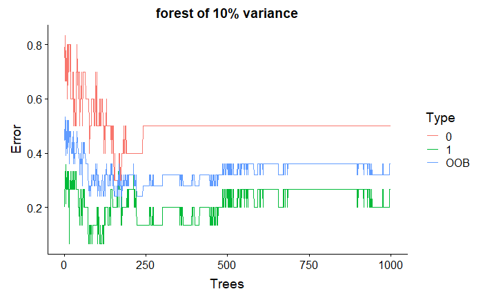

```r
#tree optimization plot for 10% tree
ggplot(data=oob.error.mirkwood5, aes(x=Trees, y=Error)) +
  geom_line(aes(color=Type))+ggtitle("forest of 10% variance")
```

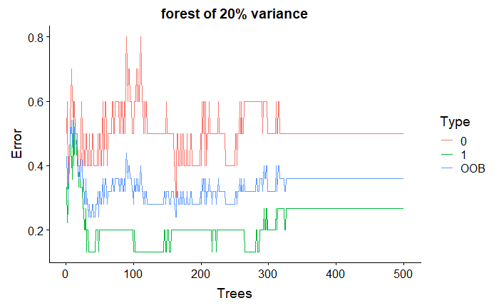

```r
#tree optimization for 20% tree
ggplot(data=oob.error.fangorn5, aes(x=Trees, y=Error)) +
  geom_line(aes(color=Type))+ggtitle("forest of 20% variance")
```

```r
set.seed(25000)
#split optimization
oob.values <- vector(length=20)
for(i in 1:20) {
  temp.model <- randomForest(drug ~ ., data=tree505, mtry=i, ntree=500)
  oob.values[i] <- temp.model$err.rate[nrow(temp.model$err.rate),1]
}
oob.values
```

```
 [1] 0.36 0.28 0.32 0.36 0.28 0.32 0.36 0.24 0.28 0.36 0.40 0.32 0.28 0.32 0.28 0.32 0.36 0.40 0.28 0.28
```

```r
oob.values <- vector(length=20)
for(i in 1:20) {
  temp.model <- randomForest(drug ~ ., data=tree510, mtry=i, ntree=1000)
  oob.values[i] <- temp.model$err.rate[nrow(temp.model$err.rate),1]
}
oob.values
```

```
 [1] 0.32 0.28 0.28 0.36 0.28 0.32 0.32 0.28 0.32 0.28 0.32 0.28 0.28 0.28 0.28 0.32 0.36 0.28 0.32 0.28
```

```r
oob.values <- vector(length=20)
for(i in 1:20) {
  temp.model <- randomForest(drug ~ ., data=tree520, mtry=i, ntree=500)
  oob.values[i] <- temp.model$err.rate[nrow(temp.model$err.rate),1]
}
oob.values
```

```
 [1] 0.36 0.28 0.32 0.28 0.28 0.28 0.32 0.32 0.32 0.32 0.32 0.28 0.28 0.32 0.28 0.28 0.28 0.32 0.24 0.28
```

```r
set.seed(25000)
#BAROOM dont be hasty now

oldForest5 <- randomForest( drug∼.,data=tree505  ,mtry=8,ntree=500)
oldForest5

mirkwood5 <- randomForest( drug∼.,data=tree510  ,mtry=3,ntree=1000)
mirkwood5

fangorn5 <- randomForest( drug∼.,data=tree520  ,mtry=19,ntree=500)
fangorn5
```

# drug 6

```r
#straping the first column of the truth set to the tree
tree620<-cbind(drug=truth_set[,6],root20)
tree620<-clean_names(tree620)
tree620$drug<-factor(tree620$drug)
tree610<-cbind(drug=truth_set[,6],root10)
tree610<-clean_names(tree610)
tree610$drug<-factor(tree610$drug)
tree605<-cbind(drug=truth_set[,6],root5)
tree605<-clean_names(tree605)
tree605$drug<-factor(tree605$drug)
```

```r
set.seed(25000)
#BAROOM dont be hasty now
oldForest6 <- randomForest( drug∼.,data=tree605  ,mtry=3,ntree=500)
oldForest6
```

```
Call:
 randomForest(formula = drug ~ ., data = tree605, mtry = 3, ntree = 500)
               Type of random forest: classification
                     Number of trees: 500
No. of variables tried at each split: 3

        OOB estimate of  error rate: 28%
Confusion matrix:
  0  1 class.error
0 7  3   0.3000000
1 4 11   0.2666667
```

```r
mirkwood6 <- randomForest( drug∼.,data=tree610  ,mtry=3,ntree=500)
mirkwood5
```

```
Call:
 randomForest(formula = drug ~ ., data = tree510, mtry = 3, ntree = 1000)
               Type of random forest: classification
                     Number of trees: 1000
No. of variables tried at each split: 3

        OOB estimate of  error rate: 36%
Confusion matrix:
  0  1 class.error
0 5  5   0.5000000
1 4 11   0.2666667
```

```r
fangorn6 <- randomForest( drug∼.,data=tree620  ,mtry=3,ntree=500)
fangorn6
```

```
Call:
 randomForest(formula = drug ~ ., data = tree620, mtry = 3, ntree = 500)
               Type of random forest: classification
                     Number of trees: 500
No. of variables tried at each split: 3

        OOB estimate of  error rate: 28%
Confusion matrix:
  0  1 class.error
0 7  3   0.3000000
1 4 11   0.2666667
```

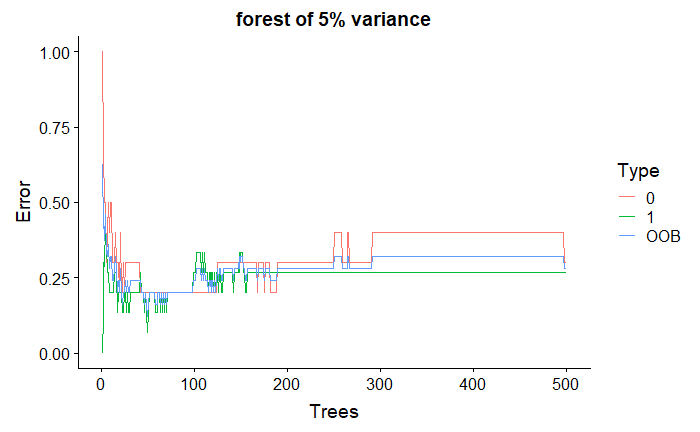

```r
#tree optimization for 5% tree
oob.error.oldForest6 <- data.frame(
  Trees=rep(1:nrow(oldForest5$err.rate), times=3),
  Type=rep(c("OOB", "1", "0"), each=nrow(oldForest6$err.rate)),
  Error=c(oldForest6$err.rate[,"OOB"],
    oldForest6$err.rate[,"1"],
    oldForest6$err.rate[,"0"]))
#tree optimization for 10% tree
oob.error.mirkwood6 <- data.frame(
  Trees=rep(1:nrow(mirkwood6$err.rate), times=3),
  Type=rep(c("OOB", "1", "0"), each=nrow(mirkwood6$err.rate)),
  Error=c(mirkwood6$err.rate[,"OOB"],
    mirkwood6$err.rate[,"1"],
    mirkwood6$err.rate[,"0"]))
#tree optimization for 20% tree
oob.error.fangorn6<- data.frame(
  Trees=rep(1:nrow(fangorn6$err.rate), times=3),
  Type=rep(c("OOB", "1", "0"), each=nrow(fangorn6$err.rate)),
  Error=c(fangorn6$err.rate[,"OOB"],
    fangorn6$err.rate[,"1"],
    fangorn6$err.rate[,"0"]))
#tree optimization plot for 5% tree
ggplot(data=oob.error.oldForest6, aes(x=Trees, y=Error)) +
  geom_line(aes(color=Type))+ggtitle("forest of 5% variance")
```

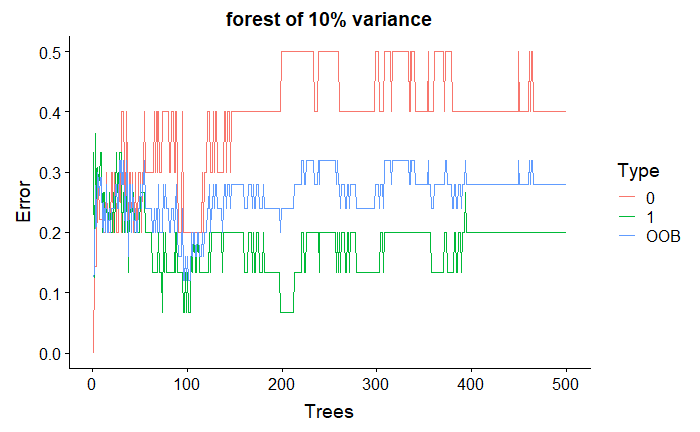

```r
#tree optimization plot for 10% tree
ggplot(data=oob.error.mirkwood6, aes(x=Trees, y=Error)) +
  geom_line(aes(color=Type))+ggtitle("forest of 10% variance")
```

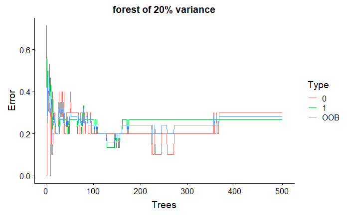

```r
#tree optimization for 20% tree
ggplot(data=oob.error.fangorn6, aes(x=Trees, y=Error)) +
  geom_line(aes(color=Type))+ggtitle("forest of 20% variance")
```

```r
set.seed(25000)
#split optimization
oob.values <- vector(length=20)
for(i in 1:20) {
  temp.model <- randomForest(drug ~ ., data=tree605, mtry=i, ntree=500)
  oob.values[i] <- temp.model$err.rate[nrow(temp.model$err.rate),1]
}
oob.values
```

```
 [1] 0.24 0.28 0.24 0.28 0.28 0.32 0.28 0.20 0.20 0.24 0.28 0.32 0.28 0.20 0.24 0.32 0.20 0.20 0.28 0.20
```

```r
oob.values <- vector(length=20)
for(i in 1:20) {
  temp.model <- randomForest(drug ~ ., data=tree610, mtry=i, ntree=500)
  oob.values[i] <- temp.model$err.rate[nrow(temp.model$err.rate),1]
}
oob.values
```

```
 [1] 0.20 0.28 0.32 0.32 0.24 0.24 0.20 0.24 0.28 0.24 0.24 0.20 0.24 0.20 0.24 0.24 0.24 0.24 0.24 0.24
```

```r
oob.values <- vector(length=20)
for(i in 1:20) {
  temp.model <- randomForest(drug ~ ., data=tree620, mtry=i, ntree=500)
  oob.values[i] <- temp.model$err.rate[nrow(temp.model$err.rate),1]
}
oob.values
```

```
 [1] 0.24 0.28 0.28 0.28 0.24 0.20 0.20 0.32 0.28 0.24 0.20 0.24 0.24 0.24 0.28 0.24 0.28 0.20 0.20 0.16
```

```r
set.seed(25000)
#BAROOM dont be hasty now

oldForest5 <- randomForest( drug∼.,data=tree605  ,mtry=8,ntree=500)
oldForest5

mirkwood5 <- randomForest( drug∼.,data=tree610  ,mtry=7,ntree=500)
mirkwood5

fangorn5 <- randomForest( drug∼.,data=tree620  ,mtry=20,ntree=500)
fangorn5
```

# drug 7

```r
#straping the first column of the truth set to the tree
tree720<-cbind(drug=truth_set[,7],root20)
tree720<-clean_names(tree720)
tree720$drug<-factor(tree720$drug)
tree710<-cbind(drug=truth_set[,7],root10)
tree710<-clean_names(tree710)
tree710$drug<-factor(tree710$drug)
tree705<-cbind(drug=truth_set[,7],root5)
tree705<-clean_names(tree705)
tree705$drug<-factor(tree705$drug)
```

```r
set.seed(25000)
#BAROOM dont be hasty now
oldForest7 <- randomForest( drug∼.,data=tree705  ,mtry=3,ntree=1500)
oldForest7
```

```
Call:
 randomForest(formula = drug ~ ., data = tree705, mtry = 3, ntree = 1500)
               Type of random forest: classification
                     Number of trees: 1500
No. of variables tried at each split: 3

        OOB estimate of  error rate: 60%
Confusion matrix:
  0  1 class.error
0 2 10   0.8333333
1 5  8   0.3846154
```

```r
mirkwood7<- randomForest( drug∼.,data=tree710  ,mtry=3,ntree=1000)
mirkwood7
```

```
Call:
 randomForest(formula = drug ~ ., data = tree710, mtry = 3, ntree = 1000)
               Type of random forest: classification
                     Number of trees: 1000
No. of variables tried at each split: 3

        OOB estimate of  error rate: 56%
Confusion matrix:
  0  1 class.error
0 2 10   0.8333333
1 4  9   0.3076923
```

```r
fangorn7 <- randomForest( drug∼.,data=tree720  ,mtry=3,ntree=2000)
fangorn7
```

```
Call:
 randomForest(formula = drug ~ ., data = tree720, mtry = 3, ntree = 2000)
               Type of random forest: classification
                     Number of trees: 2000
No. of variables tried at each split: 3

        OOB estimate of  error rate: 56%
Confusion matrix:
  0 1 class.error
0 3 9   0.7500000
1 5 8   0.3846154
```

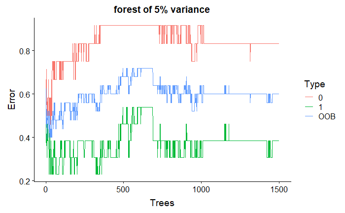

```r
#tree optimization for 5% tree
oob.error.oldForest7 <- data.frame(
  Trees=rep(1:nrow(oldForest7$err.rate), times=3),
  Type=rep(c("OOB", "1", "0"), each=nrow(oldForest7$err.rate)),
  Error=c(oldForest7$err.rate[,"OOB"],
    oldForest7$err.rate[,"1"],
    oldForest7$err.rate[,"0"]))
#tree optimization for 10% tree
oob.error.mirkwood7 <- data.frame(
  Trees=rep(1:nrow(mirkwood7$err.rate), times=3),
  Type=rep(c("OOB", "1", "0"), each=nrow(mirkwood7$err.rate)),
  Error=c(mirkwood7$err.rate[,"OOB"],
    mirkwood7$err.rate[,"1"],
    mirkwood7$err.rate[,"0"]))
#tree optimization for 20% tree
oob.error.fangorn7<- data.frame(
  Trees=rep(1:nrow(fangorn7$err.rate), times=3),
  Type=rep(c("OOB", "1", "0"), each=nrow(fangorn7$err.rate)),
  Error=c(fangorn7$err.rate[,"OOB"],
    fangorn7$err.rate[,"1"],
    fangorn7$err.rate[,"0"]))
#tree optimization plot for 5% tree
ggplot(data=oob.error.oldForest7, aes(x=Trees, y=Error)) +
  geom_line(aes(color=Type))+ggtitle("forest of 5% variance")
```

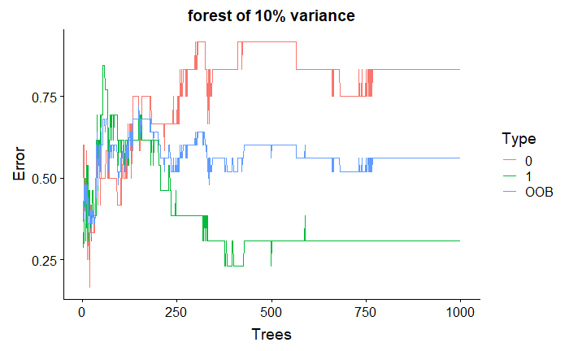

```r
#tree optimization plot for 10% tree
ggplot(data=oob.error.mirkwood7, aes(x=Trees, y=Error)) +
  geom_line(aes(color=Type))+ggtitle("forest of 10% variance")
```

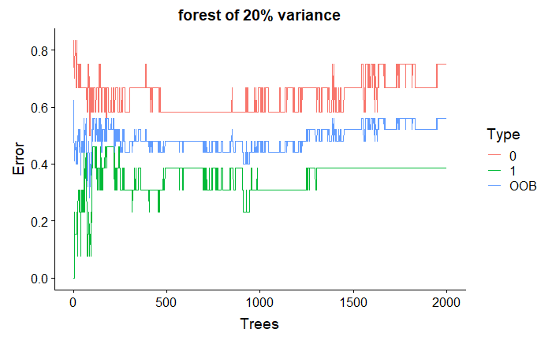

```r
#tree optimization for 20% tree
ggplot(data=oob.error.fangorn7, aes(x=Trees, y=Error)) +
  geom_line(aes(color=Type))+ggtitle("forest of 20% variance")
```

```r
set.seed(25000)
#split optimization
oob.values <- vector(length=20)
for(i in 1:20) {
  temp.model <- randomForest(drug ~ ., data=tree705, mtry=i, ntree=1500)
  oob.values[i] <- temp.model$err.rate[nrow(temp.model$err.rate),1]
}
oob.values
```

```
 [1] 0.56 0.56 0.56 0.56 0.52 0.48 0.48 0.56 0.56 0.44 0.48 0.56 0.56 0.44 0.48 0.48 0.52 0.52 0.44 0.56
```

```r
oob.values <- vector(length=20)
for(i in 1:20) {
  temp.model <- randomForest(drug ~ ., data=tree710, mtry=i, ntree=1000)
  oob.values[i] <- temp.model$err.rate[nrow(temp.model$err.rate),1]
}
oob.values
```

```
 [1] 0.64 0.48 0.56 0.48 0.48 0.60 0.52 0.44 0.48 0.52 0.44 0.56 0.60 0.48 0.40 0.40 0.56 0.60 0.48 0.52
```

```r
oob.values <- vector(length=20)
for(i in 1:20) {
  temp.model <- randomForest(drug ~ ., data=tree720, mtry=i, ntree=2000)
  oob.values[i] <- temp.model$err.rate[nrow(temp.model$err.rate),1]
}
oob.values
```

```
 [1] 0.48 0.56 0.60 0.52 0.44 0.44 0.48 0.48 0.44 0.56 0.52 0.48 0.56 0.40 0.44 0.40 0.48 0.40 0.44 0.40
```

```r
set.seed(25000)
#BAROOM dont be hasty now
#assuming 0.44 is the lowest
oldForest5 <- randomForest( drug∼.,data=tree705  ,mtry=10,ntree=1500)
oldForest5

#assuming 0.40 is the lowest
mirkwood5 <- randomForest( drug∼.,data=tree710  ,mtry=15,ntree=1000)
mirkwood5

#assuming 0.40 is the lowest
fangorn5 <- randomForest( drug∼.,data=tree720  ,mtry=14,ntree=2000)
fangorn5
```

# drug 8

```r
#straping the first column of the truth set to the tree
tree820<-cbind(drug=truth_set[,8],root20)
tree820<-clean_names(tree820)
tree820$drug<-factor(tree820$drug)
tree810<-cbind(drug=truth_set[,8],root10)
tree810<-clean_names(tree810)
tree810$drug<-factor(tree810$drug)
tree805<-cbind(drug=truth_set[,8],root5)
tree805<-clean_names(tree805)
tree805$drug<-factor(tree805$drug)
```

```r
set.seed(25000)
#BAROOM dont be hasty now
oldForest8 <- randomForest( drug∼.,data=tree805  ,mtry=3,ntree=500)
oldForest8
```

```
Call:
 randomForest(formula = drug ~ ., data = tree805, mtry = 3, ntree = 500)
               Type of random forest: classification
                     Number of trees: 500
No. of variables tried at each split: 3

        OOB estimate of  error rate: 24%
Confusion matrix:
  0  1 class.error
0 7  5  0.41666667
1 1 12  0.07692308
```

```r
mirkwood8<- randomForest( drug∼.,data=tree810  ,mtry=3,ntree=1000)
mirkwood8
```

```
Call:
 randomForest(formula = drug ~ ., data = tree810, mtry = 3, ntree = 1000)
               Type of random forest: classification
                     Number of trees: 1000
No. of variables tried at each split: 3

        OOB estimate of  error rate: 32%
Confusion matrix:
  0  1 class.error
0 5  7  0.58333333
1 1 12  0.07692308
```

```r
fangorn8 <- randomForest( drug∼.,data=tree820  ,mtry=3,ntree=1500)
fangorn8
```

```
Call:
 randomForest(formula = drug ~ ., data = tree820, mtry = 3, ntree = 1500)
               Type of random forest: classification
                     Number of trees: 1500
No. of variables tried at each split: 3

        OOB estimate of  error rate: 28%
Confusion matrix:
  0  1 class.error
0 7  5   0.4166667
1 2 11   0.1538462
```

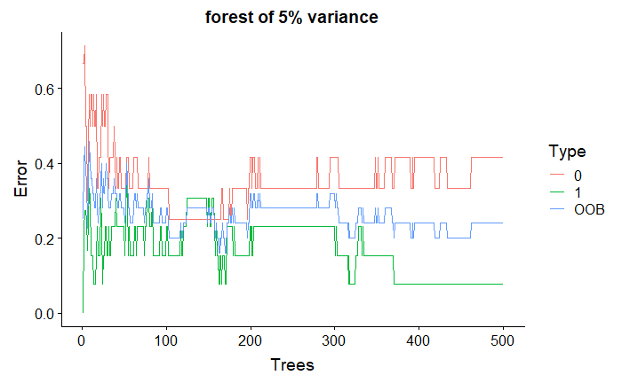

```r
#tree optimization for 5% tree
oob.error.oldForest8 <- data.frame(
  Trees=rep(1:nrow(oldForest8$err.rate), times=3),
  Type=rep(c("OOB", "1", "0"), each=nrow(oldForest8$err.rate)),
  Error=c(oldForest8$err.rate[,"OOB"],
    oldForest8$err.rate[,"1"],
    oldForest8$err.rate[,"0"]))
#tree optimization for 10% tree
oob.error.mirkwood8 <- data.frame(
  Trees=rep(1:nrow(mirkwood8$err.rate), times=3),
  Type=rep(c("OOB", "1", "0"), each=nrow(mirkwood8$err.rate)),
  Error=c(mirkwood8$err.rate[,"OOB"],
    mirkwood8$err.rate[,"1"],
    mirkwood8$err.rate[,"0"]))
#tree optimization for 20% tree
oob.error.fangorn8<- data.frame(
  Trees=rep(1:nrow(fangorn8$err.rate), times=3),
  Type=rep(c("OOB", "1", "0"), each=nrow(fangorn8$err.rate)),
  Error=c(fangorn8$err.rate[,"OOB"],
    fangorn8$err.rate[,"1"],
    fangorn8$err.rate[,"0"]))
#tree optimization plot for 5% tree
ggplot(data=oob.error.oldForest8, aes(x=Trees, y=Error)) +
  geom_line(aes(color=Type))+ggtitle("forest of 5% variance")
```

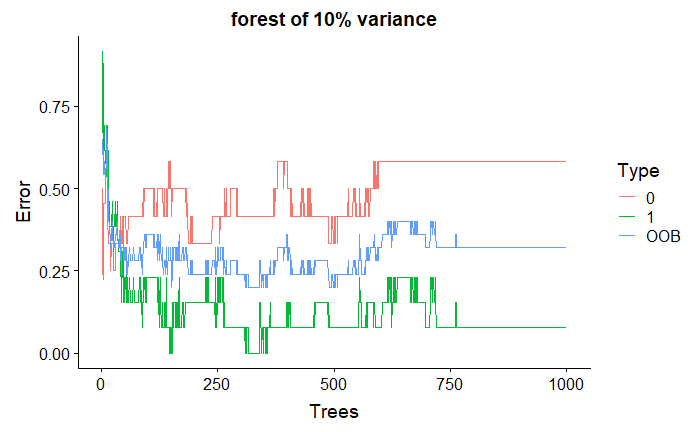

```r
#tree optimization plot for 10% tree
ggplot(data=oob.error.mirkwood8, aes(x=Trees, y=Error)) +
  geom_line(aes(color=Type))+ggtitle("forest of 10% variance")
```

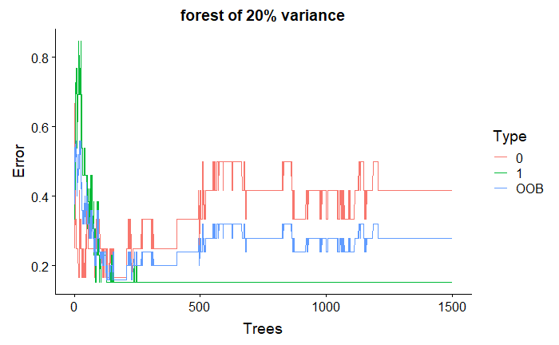

```r
#tree optimization for 20% tree
ggplot(data=oob.error.fangorn8, aes(x=Trees, y=Error)) +
  geom_line(aes(color=Type))+ggtitle("forest of 20% variance")
```

```r
set.seed(25000)
#split optimization
oob.values <- vector(length=20)
for(i in 1:20) {
  temp.model <- randomForest(drug ~ ., data=tree805, mtry=i, ntree=500)
  oob.values[i] <- temp.model$err.rate[nrow(temp.model$err.rate),1]
}
oob.values
```

```
 [1] 0.28 0.28 0.28 0.32 0.20 0.20 0.24 0.32 0.32 0.28 0.24 0.20 0.28 0.24 0.32 0.32 0.20 0.28 0.20 0.20
```

```r
oob.values <- vector(length=20)
for(i in 1:20) {
  temp.model <- randomForest(drug ~ ., data=tree810, mtry=i, ntree=1000)
  oob.values[i] <- temp.model$err.rate[nrow(temp.model$err.rate),1]
}
oob.values
```

```
 [1] 0.20 0.28 0.24 0.20 0.32 0.24 0.28 0.32 0.32 0.28 0.32 0.24 0.28 0.24 0.32 0.36 0.28 0.24 0.36 0.32
```

```r
oob.values <- vector(length=20)
for(i in 1:20) {
  temp.model <- randomForest(drug ~ ., data=tree820, mtry=i, ntree=1500)
  oob.values[i] <- temp.model$err.rate[nrow(temp.model$err.rate),1]
}
oob.values
```

```
 [1] 0.28 0.32 0.24 0.20 0.28 0.32 0.32 0.28 0.24 0.32 0.32 0.24 0.28 0.28 0.36 0.24 0.28 0.32 0.36 0.32
```

```r
set.seed(25000)
#BAROOM dont be hasty now
oldForest8 <- randomForest( drug∼.,data=tree805  ,mtry=5,ntree=500)
oldForest8
```

```
Call:
 randomForest(formula = drug ~ ., data = tree805, mtry = 5, ntree = 500)
               Type of random forest: classification
                     Number of trees: 500
No. of variables tried at each split: 5

        OOB estimate of  error rate: 28%
Confusion matrix:
  0  1 class.error
0 8  4   0.3333333
1 3 10   0.2307692
```

```r
mirkwood8 <- randomForest( drug∼.,data=tree810  ,mtry=4,ntree=1000)
mirkwood8
```

```
Call:
 randomForest(formula = drug ~ ., data = tree810, mtry = 4, ntree = 1000)
               Type of random forest: classification
                     Number of trees: 1000
No. of variables tried at each split: 4

        OOB estimate of  error rate: 24%
Confusion matrix:
  0  1 class.error
0 7  5  0.41666667
1 1 12  0.07692308
```

```r
fangorn8 <- randomForest( drug∼.,data=tree820  ,mtry=19,ntree=1000)
fangorn8
```

```
Call:
 randomForest(formula = drug ~ ., data = tree820, mtry = 19, ntree = 1000)
               Type of random forest: classification
                     Number of trees: 1000
No. of variables tried at each split: 19

        OOB estimate of  error rate: 44%
Confusion matrix:
  0  1 class.error
0 3  9   0.7500000
1 2 11   0.1538462
```

# drug 9

```r
#straping the first column of the truth set to the tree
tree920<-cbind(drug=truth_set[,9],root20)
tree920<-clean_names(tree920)
tree920$drug<-factor(tree920$drug)
tree910<-cbind(drug=truth_set[,9],root10)
tree910<-clean_names(tree910)
tree910$drug<-factor(tree910$drug)
tree905<-cbind(drug=truth_set[,9],root5)
tree905<-clean_names(tree905)
tree905$drug<-factor(tree905$drug)
```

```r
set.seed(25000)
#BAROOM dont be hasty now
oldForest9 <- randomForest( drug∼.,data=tree905  ,mtry=3,ntree=500)
oldForest9
```

```
Call:
 randomForest(formula = drug ~ ., data = tree905, mtry = 3, ntree = 500)
               Type of random forest: classification
                     Number of trees: 500
No. of variables tried at each split: 3

        OOB estimate of  error rate: 32%
Confusion matrix:
   0 1 class.error
0 12 2   0.1428571
1  6 5   0.5454545
```

```r
mirkwood9<- randomForest( drug∼.,data=tree910  ,mtry=3,ntree=1000)
mirkwood9
```

```
Call:
 randomForest(formula = drug ~ ., data = tree910, mtry = 3, ntree = 1000)
               Type of random forest: classification
                     Number of trees: 1000
No. of variables tried at each split: 3

        OOB estimate of  error rate: 52%
Confusion matrix:
  0 1 class.error
0 9 5   0.3571429
1 8 3   0.7272727
```

```r
fangorn9 <- randomForest( drug∼.,data=tree920  ,mtry=3,ntree=1500)
fangorn9
```

```
Call:
 randomForest(formula = drug ~ ., data = tree920, mtry = 3, ntree = 1500)
               Type of random forest: classification
                     Number of trees: 1500
No. of variables tried at each split: 3

        OOB estimate of  error rate: 28%
Confusion matrix:
   0 1 class.error
0 13 1  0.07142857
1  6 5  0.54545455
```

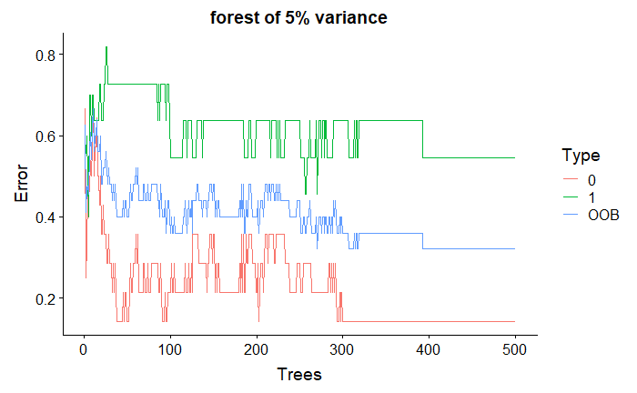

```r
#tree optimization for 5% tree
oob.error.oldForest9 <- data.frame(
  Trees=rep(1:nrow(oldForest9$err.rate), times=3),
  Type=rep(c("OOB", "1", "0"), each=nrow(oldForest9$err.rate)),
  Error=c(oldForest9$err.rate[,"OOB"],
    oldForest9$err.rate[,"1"],
    oldForest9$err.rate[,"0"]))
#tree optimization for 10% tree
oob.error.mirkwood9 <- data.frame(
  Trees=rep(1:nrow(mirkwood9$err.rate), times=3),
  Type=rep(c("OOB", "1", "0"), each=nrow(mirkwood9$err.rate)),
  Error=c(mirkwood9$err.rate[,"OOB"],
    mirkwood9$err.rate[,"1"],
    mirkwood9$err.rate[,"0"]))
#tree optimization for 20% tree
oob.error.fangorn9<- data.frame(
  Trees=rep(1:nrow(fangorn9$err.rate), times=3),
  Type=rep(c("OOB", "1", "0"), each=nrow(fangorn9$err.rate)),
  Error=c(fangorn9$err.rate[,"OOB"],
    fangorn9$err.rate[,"1"],
    fangorn9$err.rate[,"0"]))
#tree optimization plot for 5% tree
ggplot(data=oob.error.oldForest9, aes(x=Trees, y=Error)) +
  geom_line(aes(color=Type))+ggtitle("forest of 5% variance")
```

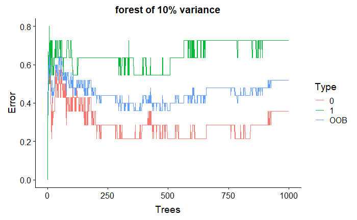

```r
#tree optimization plot for 10% tree
ggplot(data=oob.error.mirkwood9, aes(x=Trees, y=Error)) +
  geom_line(aes(color=Type))+ggtitle("forest of 10% variance")
```

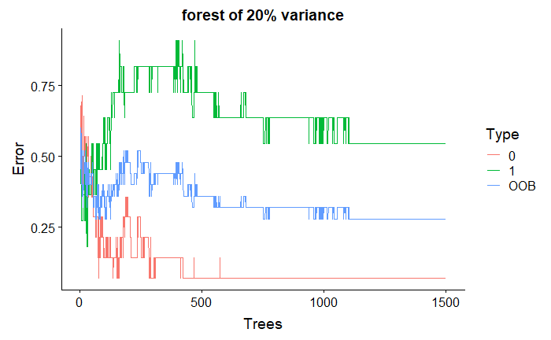

```r
#tree optimization for 20% tree
ggplot(data=oob.error.fangorn9, aes(x=Trees, y=Error)) +
  geom_line(aes(color=Type))+ggtitle("forest of 20% variance")
```

```r
set.seed(25000)
#split optimization
oob.values <- vector(length=20)
for(i in 1:20) {
  temp.model <- randomForest(drug ~ ., data=tree905, mtry=i, ntree=500)
  oob.values[i] <- temp.model$err.rate[nrow(temp.model$err.rate),1]
}
oob.values
```

```
 [1] 0.60 0.36 0.36 0.40 0.40 0.44 0.40 0.44 0.36 0.32 0.44 0.40 0.44 0.36 0.32 0.36 0.44 0.44 0.44 0.40
```

```r
oob.values <- vector(length=20)
for(i in 1:20) {
  temp.model <- randomForest(drug ~ ., data=tree910, mtry=i, ntree=1000)
  oob.values[i] <- temp.model$err.rate[nrow(temp.model$err.rate),1]
}
oob.values
```

```
 [1] 0.36 0.36 0.48 0.44 0.36 0.44 0.40 0.36 0.32 0.40 0.44 0.40 0.40 0.32 0.44 0.44 0.32 0.32 0.40 0.40
```

```r
oob.values <- vector(length=20)
for(i in 1:20) {
  temp.model <- randomForest(drug ~ ., data=tree920, mtry=i, ntree=1500)
  oob.values[i] <- temp.model$err.rate[nrow(temp.model$err.rate),1]
}
oob.values
```

```
 [1] 0.40 0.40 0.48 0.28 0.48 0.32 0.32 0.40 0.36 0.32 0.36 0.36 0.40 0.36 0.40 0.40 0.36 0.40 0.40 0.36
```

```r
set.seed(25000)
#BAROOM dont be hasty now

#assuming that 0.32 is the lowest
oldForest9 <- randomForest( drug∼.,data=tree905  ,mtry=10,ntree=500)
oldForest9

#assuming that 0.32 is the lowest
mirkwood9 <- randomForest( drug∼.,data=tree910  ,mtry=9,ntree=1000)
mirkwood9

#assuming that 0.28 is the lowest
fangorn9 <- randomForest( drug∼.,data=tree920  ,mtry=4,ntree=1500)
fangorn9
```